# Effectiveness of Sweden's Response to COVID-19

While many countries have chosen to implement strict social distancing measures to prevent the spread of the novel coronavirus, Sweden has taken a much more lenient stance and allowed businesses and gatherings to continue per usual. This project looks to examine the effect of this policy on their death rate relative to what their predicted death toll might be relative to certain risk factors. The information obtained from these databases is accurate up to May 1, 2020.

```python
import math
import numpy as np
import pandas as pd
import matplotlib.pyplot as plt
import seaborn as sns
import statsmodels.api as sm
import io
import requests

from matplotlib.pyplot import*
from scipy.interpolate import*
from numpy import*
from IPython.display import Markdown as md
```

```python
# display entire dataframes
pd.set_option('display.max_rows', None)
pd.set_option('display.max_columns', None)
pd.set_option('display.width', 10)
pd.set_option('display.max_colwidth', None)
```

We first gather all of our data sources and clean a bit of data:

```python
# obtain global data for noncommunicable diseases (ncd)
# source: https://apps.who.int/gho/data/node.main.NCDDEATHCAUSESNUMBER?lang=en
ncdPath = '../Covid-19/SDG_SH_DTH_RNCOM.csv'
allNCD = pd.read_csv(ncdPath, index_col=0)

# filter to latest year (2016)
ncd = allNCD[allNCD.iloc[:,0].str.strip()=='2016']

# create new columns for easier dataframe merging later
ncd = ncd.rename(columns={ncd.columns[2]: "Deaths" })
ncd["Diabetes_Deaths"] = ncd.iloc[:,1].str.contains("Diabetes") * ncd.Deaths
ncd["CVD_Deaths"] = ncd.iloc[:,1].str.contains("Cardiovascular") * ncd.Deaths
ncd["COPD_Deaths"] = ncd.iloc[:,1].str.contains("Chronic") * ncd.Deaths
ncd = ncd.replace('',nan)
ncd.iloc[:,-3:] = ncd.iloc[:,-3:].astype(float)

# rename certain countries for merging later
ncd = ncd.rename(index={'United States of America' : 'United States'})
ncd = ncd.rename(index={'Viet Nam' : 'Vietnam'})
ncd = ncd.rename(index={'Russian Federation' : 'Russia'})
ncd = ncd.rename(index={'Republic of Moldova' : 'Moldova'})
ncd = ncd.rename(index={'Republic of Korea' : 'South Korea'})
ncd = ncd.rename(index={'Iran (Islamic Republic of)' : 'Iran'})
ncd = ncd.rename(index={'Bolivia (Plurinational State of)' : 'Bolivia'})
```

```python
# read the data for global covid deaths
# dataset updated daily
globalDeathsURL="https://data.humdata.org/hxlproxy/api/data-preview.csv?url=https%3A%2F%2Fraw.githubusercontent.com%2FCSSEGISandData%2FCOVID-19%2Fmaster%2Fcsse_covid_19_data%2Fcsse_covid_19_time_series%2Ftime_series_covid19_deaths_global.csv&filename=time_series_covid19_deaths_global.csv"
s=requests.get(globalDeathsURL).content
globalDeaths=pd.read_csv(io.StringIO(s.decode('utf-8')))

# group provinces togther into a single country
globalDeaths = globalDeaths.groupby('Country/Region').sum().drop(['Lat','Long'],axis=1)
globalDeaths = globalDeaths.rename({'US' : 'United States'})
```

```python
# read the data for global covid cases
# dataset updated daily
globalCasesURL="https://data.humdata.org/hxlproxy/api/data-preview.csv?url=https%3A%2F%2Fraw.githubusercontent.com%2FCSSEGISandData%2FCOVID-19%2Fmaster%2Fcsse_covid_19_data%2Fcsse_covid_19_time_series%2Ftime_series_covid19_confirmed_global.csv&filename=time_series_covid19_confirmed_global.csv"
s=requests.get(globalCasesURL).content
globalCases=pd.read_csv(io.StringIO(s.decode('utf-8')))

# group provinces togther into a single country
globalCases = globalCases.groupby('Country/Region').sum().drop(['Lat','Long'],axis=1)
globalCases = globalCases.rename({'US' : 'United States'})
```

```python
# source: https://www.kaggle.com/lin0li/covid19testing
# data for global covid tests
# up to date as of May 1, 2020
testedPath = '../Covid-19/tested_worldwide.csv'
tested = pd.read_csv(testedPath, index_col=0)

# gather the total number of tests
tested = tested.groupby('Country_Region').max()
tested = tested.rename(columns={'total_tested' : "Total_Tests"})
```

```python
# data for country stats
# source: https://www.kaggle.com/sudalairajkumar/undata-country-profiles
allCountriesPath = '../Covid-19/country_profile_variables.csv'
allCountries = pd.read_csv(allCountriesPath, index_col=0)
allCountries = allCountries.rename(columns={"Population in thousands (2017)" : "Population",
                                            "Urban population (% of total population)" : "Urban_Population_Percent",
                                            "GDP per capita (current US$)" : "GDP_per_Capita",
                                            "Health: Total expenditure (% of GDP)" : "Health_Expenditure"
                                           })

allCountries['Population'] = allCountries['Population']*1000
```

More cleaning and merging into a succint dataframe:

```python
# correct data format for life expectancy
avgLifeExp = allCountries['Life expectancy at birth (females/males, years)'].str.split("/")
avgLifeExp = avgLifeExp.apply(lambda x: (float(x[0])+float(x[1]))/2 if (x[0] != "..." and len(x)>1) else "N/A")
allCountries['Life_Expectancy'] = avgLifeExp

over60 = allCountries['Population age distribution (0-14 / 60+ years, %)'].str.split("/")
over60 = over60.apply(lambda x: float(x[1]) if (x[0] != "..." and len(x)>1) else "N/A")
allCountries['Percent_Over_60'] = over60

# only consider countries with populations between half a million and one blllion people
countryInfo = allCountries[(allCountries['Population'] > 500000) & (allCountries['Population'] < 1000000000)]

# condensing dataframe to only relevant columns
countryInfo = countryInfo[['Population', 'Urban_Population_Percent', 'GDP_per_Capita','Life_Expectancy','Percent_Over_60','Health_Expenditure']]

globalDeaths = globalDeaths.rename(columns={ globalDeaths.columns[-1]: "Total_Covid_Deaths" })
globalCases = globalCases.rename(columns={ globalCases.columns[-1]: "Total_Confirmed_Covid_Cases" })

# manually correct inconsistencies
countryInfo = countryInfo.rename(index={'United States of America' : 'United States'})
countryInfo = countryInfo.rename(index={'Viet Nam' : 'Vietnam'})
countryInfo = countryInfo.rename(index={'Russian Federation' : 'Russia'})
countryInfo = countryInfo.rename(index={'Republic of Moldova' : 'Moldova'})
countryInfo = countryInfo.rename(index={'Republic of Korea' : 'South Korea'})
countryInfo = countryInfo.rename(index={'Iran (Islamic Republic of)' : 'Iran'})
countryInfo = countryInfo.rename(index={'Bolivia (Plurinational State of)' : 'Bolivia'})

# join the dataframes together and create new columns
countryInfo = countryInfo.join(tested['Total_Tests'])
countryInfo["Tests_per_Million"] = countryInfo.Total_Tests/countryInfo.Population * 1000000
countryInfo = countryInfo.join(globalCases.iloc[:,-1])
countryInfo["Cases_per_Million"] = countryInfo.Total_Confirmed_Covid_Cases/countryInfo.Population * 1000000
countryInfo = countryInfo.join(globalDeaths.iloc[:,-1])
countryInfo["Covid_Deaths_per_Million"] = countryInfo.Total_Covid_Deaths/countryInfo.Population * 1000000
countryInfo = countryInfo.join(ncd['Diabetes_Deaths'])
countryInfo["Diabetes_Deaths_per_Million"] = countryInfo.Diabetes_Deaths/countryInfo.Population * 1000000
countryInfo = countryInfo.join(ncd['CVD_Deaths'])
countryInfo["CVD_Deaths_per_Million"] = countryInfo.CVD_Deaths/countryInfo.Population * 1000000
countryInfo = countryInfo.join(ncd['COPD_Deaths'])
countryInfo["COPD_Deaths_per_Million"] = countryInfo.COPD_Deaths/countryInfo.Population * 1000000

# get rid of null values
countryInfo = countryInfo.dropna()

# replace missing values for 3 countries with the mean
countryInfo.Health_Expenditure.replace({-99: countryInfo.Health_Expenditure.mean()}, inplace=True)

countryInfo = countryInfo.astype(float)
```

```python
# display the countries we will model sorted by their covid-19 death rate
countryInfo.sort_values(by='Covid_Deaths_per_Million', ascending=False)
```

|  | Population | Urban_Population_Percent | GDP_per_Capita | Life_Expectancy | Percent_Over_60 | Health_Expenditure | Total_Tests | Tests_per_Million | Total_Confirmed_Covid_Cases | Cases_per_Million | Total_Covid_Deaths | Covid_Deaths_per_Million | Diabetes_Deaths | Diabetes_Deaths_per_Million | CVD_Deaths | CVD_Deaths_per_Million | COPD_Deaths | COPD_Deaths_per_Million |
| --- | --- | --- | --- | --- | --- | --- | --- | --- | --- | --- | --- | --- | --- | --- | --- | --- | --- | --- |
| Belgium | 11429000.0 | 97.9 | 40277.8 | 80.50 | 24.6 | 10.6 | 306936.0 | 26855.892904 | 50781.0 | 4443.170881 | 8339.0 | 729.635139 | 1683.0 | 147.256978 | 30963.0 | 2709.160906 | 8648.0 | 756.671625 |
| Spain | 46354000.0 | 79.6 | 25865.4 | 82.45 | 25.3 | 9.0 | 600000.0 | 12943.866764 | 220325.0 | 4753.095741 | 25857.0 | 557.815938 | 10074.0 | 217.327523 | 118199.0 | 2549.920179 | 43187.0 | 931.677957 |
| Italy | 59360000.0 | 69.0 | 30462.4 | 82.30 | 29.4 | 9.2 | 2053425.0 | 34592.739218 | 214457.0 | 3612.820081 | 29684.0 | 500.067385 | 22112.0 | 372.506739 | 229802.0 | 3871.327493 | 41311.0 | 695.940027 |
| France | 64980000.0 | 79.5 | 36304.2 | 81.90 | 25.7 | 11.5 | 365589.0 | 5626.177285 | 174224.0 | 2681.194214 | 25812.0 | 397.229917 | 12375.0 | 190.443213 | 143401.0 | 2206.848261 | 31072.0 | 478.177901 |
| Netherlands | 17036000.0 | 90.5 | 44332.1 | 81.25 | 25.0 | 10.9 | 165012.0 | 9686.076544 | 41518.0 | 2437.074431 | 5221.0 | 306.468655 | 3030.0 | 177.858652 | 38132.0 | 2238.318854 | 10843.0 | 636.475699 |
| Sweden | 9911000.0 | 85.8 | 50687.5 | 81.85 | 25.5 | 11.9 | 119154.0 | 12022.399354 | 23918.0 | 2413.278176 | 2941.0 | 296.740995 | 2124.0 | 214.307335 | 31646.0 | 3193.017859 | 5214.0 | 526.082131 |
| Ireland | 4762000.0 | 63.2 | 60513.6 | 80.85 | 19.1 | 7.8 | 90646.0 | 19035.279294 | 22248.0 | 4671.986560 | 1375.0 | 288.744225 | 572.0 | 120.117598 | 8745.0 | 1836.413272 | 2735.0 | 574.338513 |
| United States | 324460000.0 | 81.6 | 56053.8 | 78.85 | 21.5 | 17.1 | 6231182.0 | 19204.777168 | 1228603.0 | 3786.608519 | 73431.0 | 226.317574 | 84332.0 | 259.914936 | 837250.0 | 2580.441349 | 246944.0 | 761.092276 |
| Switzerland | 8476000.0 | 73.9 | 80831.1 | 82.65 | 24.1 | 11.7 | 227554.0 | 26846.861727 | 30060.0 | 3546.484191 | 1805.0 | 212.954224 | 1381.0 | 162.930628 | 21325.0 | 2515.927324 | 3625.0 | 427.678150 |
| Luxembourg | 584000.0 | 90.2 | 100160.8 | 81.10 | 19.6 | 6.9 | 36087.0 | 61792.808219 | 3851.0 | 6594.178082 | 98.0 | 167.808219 | 89.0 | 152.397260 | 1190.0 | 2037.671233 | 267.0 | 457.191781 |
| Canada | 36624000.0 | 81.8 | 43205.6 | 81.75 | 23.5 | 10.4 | 832222.0 | 22723.405417 | 64694.0 | 1766.437309 | 4366.0 | 119.211446 | 6941.0 | 189.520533 | 63683.0 | 1738.832460 | 18610.0 | 508.136741 |
| Portugal | 10330000.0 | 63.5 | 19239.2 | 80.40 | 27.9 | 9.5 | 235878.0 | 22834.269119 | 26182.0 | 2534.559535 | 1089.0 | 105.421104 | 4715.0 | 456.437561 | 31045.0 | 3005.324298 | 7155.0 | 692.642788 |
| Ecuador | 16625000.0 | 63.7 | 6205.1 | 75.60 | 10.5 | 9.2 | 32453.0 | 1952.060150 | 31881.0 | 1917.654135 | 1618.0 | 97.323308 | 6507.0 | 391.398496 | 19848.0 | 1193.864662 | 4360.0 | 262.255639 |
| Germany | 82114000.0 | 75.3 | 41686.2 | 80.40 | 28.0 | 11.3 | 1728357.0 | 21048.262172 | 168162.0 | 2047.909005 | 7275.0 | 88.596342 | 24764.0 | 301.580729 | 343531.0 | 4183.586234 | 58839.0 | 716.552598 |
| Denmark | 5734000.0 | 87.7 | 53149.3 | 80.15 | 25.3 | 10.8 | 132967.0 | 23189.222183 | 10136.0 | 1767.701430 | 506.0 | 88.245553 | 1485.0 | 258.981514 | 12484.0 | 2177.188699 | 4760.0 | 830.136031 |
| Iran | 81163000.0 | 73.4 | 5038.1 | 75.10 | 8.8 | 7.5 | 365723.0 | 4506.031073 | 101650.0 | 1252.417974 | 6418.0 | 79.075441 | 14842.0 | 182.866577 | 160823.0 | 1981.481710 | 14552.0 | 179.293520 |
| Austria | 8736000.0 | 66.0 | 44117.7 | 80.95 | 25.1 | 11.2 | 221089.0 | 25307.806777 | 15684.0 | 1795.329670 | 608.0 | 69.597070 | 3402.0 | 389.423077 | 33017.0 | 3779.418498 | 4108.0 | 470.238095 |
| Panama | 4099000.0 | 66.6 | 13268.1 | 77.40 | 11.4 | 8.0 | 17850.0 | 4354.720664 | 7731.0 | 1886.069773 | 218.0 | 53.183703 | 1428.0 | 348.377653 | 5532.0 | 1349.597463 | 1303.0 | 317.882410 |
| Peru | 32166000.0 | 78.6 | 6069.1 | 74.15 | 10.4 | 5.5 | 198349.0 | 6166.417957 | 54817.0 | 1704.190760 | 1533.0 | 47.659019 | 6062.0 | 188.459864 | 35815.0 | 1113.442766 | 9700.0 | 301.560654 |
| Slovenia | 2080000.0 | 49.7 | 20689.8 | 80.20 | 26.3 | 9.2 | 40580.0 | 19509.615385 | 1448.0 | 696.153846 | 99.0 | 47.596154 | 340.0 | 163.461538 | 7988.0 | 3840.384615 | 742.0 | 356.730769 |
| Finland | 5523000.0 | 84.2 | 42148.1 | 80.70 | 27.8 | 9.7 | 74527.0 | 13493.934456 | 5573.0 | 1009.053051 | 252.0 | 45.627376 | 510.0 | 92.341119 | 19060.0 | 3451.022995 | 1742.0 | 315.408293 |
| Turkey | 80745000.0 | 73.4 | 9125.8 | 74.80 | 12.0 | 5.4 | 1075048.0 | 13314.112329 | 131744.0 | 1631.605672 | 3584.0 | 44.386649 | 21788.0 | 269.837142 | 156616.0 | 1939.637129 | 30282.0 | 375.032510 |
| Romania | 19679000.0 | 54.6 | 9120.7 | 74.90 | 24.9 | 5.6 | 126645.0 | 6435.540424 | 14107.0 | 716.855531 | 864.0 | 43.904670 | 2705.0 | 137.456172 | 145284.0 | 7382.692210 | 9349.0 | 475.074953 |
| Estonia | 1310000.0 | 67.5 | 17112.0 | 76.50 | 25.9 | 6.4 | 53763.0 | 41040.458015 | 1713.0 | 1307.633588 | 55.0 | 41.984733 | 152.0 | 116.030534 | 7840.0 | 5984.732824 | 345.0 | 263.358779 |
| Brazil | 209288000.0 | 85.7 | 8528.3 | 74.70 | 12.6 | 8.3 | 476272.0 | 2275.677535 | 126611.0 | 604.960628 | 8588.0 | 41.034364 | 65381.0 | 312.397271 | 369072.0 | 1763.464699 | 84749.0 | 404.939605 |
| Norway | 5305000.0 | 80.5 | 74185.5 | 81.55 | 22.3 | 9.7 | 152095.0 | 28670.122526 | 7996.0 | 1507.257304 | 216.0 | 40.716305 | 681.0 | 128.369463 | 11616.0 | 2189.632422 | 3136.0 | 591.140434 |
| Hungary | 9722000.0 | 71.2 | 12350.6 | 75.25 | 26.0 | 7.4 | 55390.0 | 5697.387369 | 3111.0 | 319.995886 | 373.0 | 38.366591 | 2789.0 | 286.875129 | 61463.0 | 6322.053075 | 6538.0 | 672.495371 |
| Israel | 8322000.0 | 92.1 | 37129.4 | 81.85 | 16.1 | 7.8 | 311407.0 | 37419.730834 | 16310.0 | 1959.865417 | 239.0 | 28.719058 | 2676.0 | 321.557318 | 10565.0 | 1269.526556 | 2804.0 | 336.938236 |
| Czechia | 10618000.0 | 73.0 | 17561.7 | 78.15 | 25.6 | 7.4 | 249634.0 | 23510.453946 | 7974.0 | 750.988887 | 262.0 | 24.675080 | 3818.0 | 359.578075 | 47334.0 | 4457.901676 | 4680.0 | 440.760972 |
| Bosnia and Herzegovina | 3507000.0 | 39.8 | 4265.0 | 76.25 | 23.4 | 9.6 | 21432.0 | 6111.206159 | 1987.0 | 566.581123 | 86.0 | 24.522384 | 2552.0 | 727.687482 | 20279.0 | 5782.435130 | 1448.0 | 412.888509 |
| Serbia | 8791000.0 | 55.6 | 5238.6 | 74.65 | 24.5 | 10.4 | 78942.0 | 8979.865772 | 9791.0 | 1113.752702 | 203.0 | 23.091798 | 3063.0 | 348.424525 | 57465.0 | 6536.798999 | 5514.0 | 627.232397 |
| Mexico | 129163000.0 | 79.2 | 8980.9 | 76.45 | 10.1 | 6.3 | 36594.0 | 283.316430 | 27634.0 | 213.946718 | 2704.0 | 20.934788 | 99623.0 | 771.296734 | 159256.0 | 1232.984678 | 36494.0 | 282.542214 |
| Croatia | 4189000.0 | 59.0 | 11479.4 | 77.00 | 26.8 | 7.8 | 24186.0 | 5773.693005 | 2119.0 | 505.848651 | 85.0 | 20.291239 | 1904.0 | 454.523753 | 23084.0 | 5510.623060 | 2016.0 | 481.260444 |
| Poland | 38171000.0 | 60.5 | 12355.5 | 76.95 | 24.0 | 6.4 | 354628.0 | 9290.508501 | 14740.0 | 386.157030 | 733.0 | 19.203060 | 8721.0 | 228.471877 | 181988.0 | 4767.703230 | 17892.0 | 468.732808 |
| United Arab Emirates | 9400000.0 | 85.5 | 40438.8 | 77.10 | 2.4 | 3.6 | 839000.0 | 89255.319149 | 15738.0 | 1674.255319 | 157.0 | 16.702128 | 707.0 | 75.212766 | 5970.0 | 635.106383 | 825.0 | 87.765957 |
| Lithuania | 2890000.0 | 66.5 | 14383.7 | 73.90 | 25.3 | 6.6 | 132768.0 | 45940.484429 | 1428.0 | 494.117647 | 48.0 | 16.608997 | 307.0 | 106.228374 | 23167.0 | 8016.262976 | 699.0 | 241.868512 |
| Chile | 18055000.0 | 89.5 | 13416.2 | 78.75 | 16.0 | 7.8 | 108891.0 | 6031.071725 | 23048.0 | 1276.543894 | 281.0 | 15.563556 | 5171.0 | 286.402659 | 29698.0 | 1644.862919 | 7064.0 | 391.248962 |
| Armenia | 2930000.0 | 62.7 | 3489.1 | 73.80 | 16.9 | 4.5 | 22216.0 | 7582.252560 | 2782.0 | 949.488055 | 40.0 | 13.651877 | 1093.0 | 373.037543 | 12288.0 | 4193.856655 | 1156.0 | 394.539249 |
| Greece | 11160000.0 | 78.0 | 17788.0 | 80.65 | 26.5 | 8.1 | 75170.0 | 6735.663082 | 2663.0 | 238.620072 | 147.0 | 13.172043 | 1769.0 | 158.512545 | 46098.0 | 4130.645161 | 10499.0 | 940.770609 |
| Montenegro | 629000.0 | 64.0 | 6424.1 | 76.40 | 21.3 | 6.4 | 5645.0 | 8974.562798 | 324.0 | 515.103339 | 8.0 | 12.718601 | 160.0 | 254.372019 | 3786.0 | 6019.077901 | 186.0 | 295.707472 |
| Bulgaria | 7085000.0 | 73.9 | 6846.8 | 74.30 | 27.7 | 8.4 | 26417.0 | 3728.581510 | 1778.0 | 250.952717 | 84.0 | 11.856034 | 1585.0 | 223.712068 | 67831.0 | 9573.888497 | 4612.0 | 650.952717 |
| Belarus | 9468000.0 | 76.7 | 5750.8 | 72.10 | 21.3 | 5.7 | 139295.0 | 14712.188424 | 19255.0 | 2033.692438 | 112.0 | 11.829320 | 404.0 | 42.670046 | 73656.0 | 7779.467681 | 2172.0 | 229.404309 |
| Russia | 143990000.0 | 74.0 | 9243.3 | 70.30 | 21.1 | 7.1 | 3723807.0 | 25861.566775 | 165929.0 | 1152.364748 | 1537.0 | 10.674352 | 9812.0 | 68.143621 | 1022790.0 | 7103.201611 | 33346.0 | 231.585527 |
| Albania | 2930000.0 | 57.4 | 3984.2 | 77.75 | 19.0 | 5.9 | 6768.0 | 2309.897611 | 832.0 | 283.959044 | 31.0 | 10.580205 | 168.0 | 57.337884 | 14930.0 | 5095.563140 | 887.0 | 302.730375 |
| Latvia | 1950000.0 | 67.4 | 13704.1 | 73.75 | 26.2 | 5.9 | 61120.0 | 31343.589744 | 900.0 | 461.538462 | 17.0 | 8.717949 | 494.0 | 253.333333 | 15901.0 | 8154.358974 | 421.0 | 215.897436 |
| Bolivia | 11052000.0 | 68.5 | 3076.8 | 67.75 | 9.5 | 6.3 | 3900.0 | 352.877307 | 1886.0 | 170.647847 | 91.0 | 8.233804 | 2867.0 | 259.410062 | 16707.0 | 1511.672096 | 3304.0 | 298.950416 |
| Colombia | 49066000.0 | 76.4 | 6056.1 | 73.80 | 11.6 | 7.2 | 41765.0 | 851.200424 | 8959.0 | 182.590796 | 397.0 | 8.091143 | 9732.0 | 198.345086 | 83987.0 | 1711.714833 | 18272.0 | 372.396364 |
| Ukraine | 44223000.0 | 69.7 | 2021.6 | 71.05 | 23.2 | 7.1 | 118545.0 | 2680.618683 | 13184.0 | 298.125410 | 327.0 | 7.394342 | 2546.0 | 57.571852 | 402391.0 | 9099.133935 | 13068.0 | 295.502340 |
| Philippines | 104918000.0 | 44.4 | 2904.2 | 68.75 | 7.6 | 4.7 | 81292.0 | 774.814617 | 10004.0 | 95.350655 | 658.0 | 6.271564 | 25528.0 | 243.313826 | 233190.0 | 2222.592882 | 42243.0 | 402.628720 |
| Argentina | 44271000.0 | 91.8 | 14564.5 | 76.00 | 15.4 | 4.8 | 36611.0 | 826.974769 | 5208.0 | 117.639087 | 273.0 | 6.166565 | 9233.0 | 208.556391 | 91028.0 | 2056.154142 | 34425.0 | 777.597073 |
| Trinidad and Tobago | 1369000.0 | 8.4 | 19062.9 | 70.35 | 15.0 | 5.9 | 1298.0 | 948.137327 | 116.0 | 84.733382 | 8.0 | 5.843682 | 1860.0 | 1358.655953 | 3945.0 | 2881.665449 | 405.0 | 295.836377 |
| Bahrain | 1493000.0 | 88.8 | 22600.2 | 76.55 | 4.6 | 5.0 | 107273.0 | 71850.636303 | 3934.0 | 2634.963161 | 8.0 | 5.358339 | 404.0 | 270.596115 | 775.0 | 519.089082 | 96.0 | 64.300067 |
| Uruguay | 3457000.0 | 95.3 | 15573.8 | 76.80 | 19.5 | 8.6 | 12478.0 | 3609.487995 | 673.0 | 194.677466 | 17.0 | 4.917559 | 934.0 | 270.176454 | 9233.0 | 2670.812844 | 2671.0 | 772.635233 |
| Slovakia | 5448000.0 | 53.6 | 16082.5 | 76.20 | 21.8 | 8.1 | 85922.0 | 15771.292217 | 1429.0 | 262.298091 | 25.0 | 4.588840 | 944.0 | 173.274596 | 20548.0 | 3771.659325 | 1335.0 | 245.044053 |
| New Zealand | 4706000.0 | 86.3 | 38294.3 | 81.30 | 20.8 | 11.0 | 139898.0 | 29727.581810 | 1489.0 | 316.404590 | 21.0 | 4.462388 | 880.0 | 186.995325 | 9477.0 | 2013.812155 | 2209.0 | 469.400765 |
| Japan | 127484000.0 | 93.5 | 34628.7 | 83.20 | 33.4 | 10.2 | 141600.0 | 1110.727621 | 15253.0 | 119.646387 | 556.0 | 4.361332 | 14446.0 | 113.316181 | 358702.0 | 2813.702112 | 115041.0 | 902.395595 |
| Australia | 24451000.0 | 89.4 | 51352.2 | 82.30 | 21.0 | 9.4 | 588868.0 | 24083.595763 | 6894.0 | 281.951658 | 97.0 | 3.967118 | 4754.0 | 194.429676 | 44042.0 | 1801.235123 | 11738.0 | 480.062165 |
| Singapore | 5709000.0 | 100.0 | 52239.0 | 82.30 | 19.5 | 4.9 | 143919.0 | 25209.143458 | 20198.0 | 3537.922578 | 20.0 | 3.503240 | 400.0 | 70.064810 | 8184.0 | 1433.526012 | 865.0 | 151.515152 |
| Indonesia | 263991000.0 | 53.7 | 3346.5 | 68.65 | 8.6 | 2.8 | 39422.0 | 149.330848 | 12438.0 | 47.115243 | 895.0 | 3.390267 | 102800.0 | 389.407215 | 655055.0 | 2481.353531 | 103704.0 | 392.831574 |
| Malaysia | 31624000.0 | 74.7 | 9768.4 | 74.85 | 9.7 | 4.2 | 121722.0 | 3849.038705 | 6428.0 | 203.263344 | 107.0 | 3.383506 | 4635.0 | 146.565899 | 53977.0 | 1706.836580 | 6300.0 | 199.215785 |
| Jamaica | 2890000.0 | 54.8 | 5105.8 | 75.50 | 13.6 | 5.4 | 442.0 | 152.941176 | 478.0 | 165.397924 | 9.0 | 3.114187 | 2340.0 | 809.688581 | 5866.0 | 2029.757785 | 639.0 | 221.107266 |
| Pakistan | 197016000.0 | 38.8 | 1410.4 | 65.90 | 6.7 | 2.6 | 98522.0 | 500.071060 | 24073.0 | 122.188046 | 564.0 | 2.862712 | 44666.0 | 226.712551 | 411569.0 | 2089.013075 | 71484.0 | 362.833475 |
| Azerbaijan | 9828000.0 | 54.6 | 5438.7 | 71.60 | 10.1 | 6.0 | 95747.0 | 9742.266992 | 2127.0 | 216.422466 | 28.0 | 2.849003 | 1475.0 | 150.081400 | 32390.0 | 3295.685796 | 1911.0 | 194.444444 |
| South Africa | 56717000.0 | 64.8 | 5773.0 | 59.55 | 8.4 | 8.8 | 152390.0 | 2686.848740 | 7808.0 | 137.665956 | 153.0 | 2.697604 | 37228.0 | 656.381685 | 97559.0 | 1720.101557 | 23526.0 | 414.796269 |
| Kyrgyzstan | 6045000.0 | 35.7 | 1106.4 | 70.35 | 7.6 | 6.5 | 31460.0 | 5204.301075 | 871.0 | 144.086022 | 12.0 | 1.985112 | 428.0 | 70.802316 | 19277.0 | 3188.916460 | 1509.0 | 249.627792 |
| Kazakhstan | 18204000.0 | 53.2 | 10312.1 | 69.10 | 11.1 | 4.4 | 40347.0 | 2216.381015 | 4422.0 | 242.913645 | 30.0 | 1.647989 | 1334.0 | 73.280598 | 73860.0 | 4057.350033 | 6614.0 | 363.326741 |
| Costa Rica | 4906000.0 | 76.8 | 11015.0 | 79.20 | 13.6 | 9.3 | 13240.0 | 2698.736241 | 761.0 | 155.116184 | 6.0 | 1.222992 | 916.0 | 186.710151 | 7227.0 | 1473.094170 | 1610.0 | 328.169588 |
| Bangladesh | 164670000.0 | 34.3 | 1207.9 | 71.35 | 7.3 | 2.8 | 70239.0 | 426.543997 | 11719.0 | 71.166576 | 186.0 | 1.129532 | 28065.0 | 170.431773 | 257555.0 | 1564.067529 | 82293.0 | 499.744944 |
| Thailand | 69038000.0 | 50.4 | 5814.8 | 74.60 | 16.9 | 4.1 | 35500.0 | 514.209566 | 2989.0 | 43.294997 | 55.0 | 0.796663 | 23929.0 | 346.606217 | 124722.0 | 1806.570295 | 30746.0 | 445.348938 |
| Nigeria | 190886000.0 | 47.8 | 2714.5 | 51.90 | 4.5 | 3.7 | 7153.0 | 37.472628 | 3145.0 | 16.475802 | 103.0 | 0.539589 | 25811.0 | 135.216831 | 225602.0 | 1181.867712 | 32984.0 | 172.794233 |
| Nepal | 29305000.0 | 18.6 | 724.5 | 68.90 | 8.8 | 5.8 | 47495.0 | 1620.713189 | 99.0 | 3.378263 | 0.0 | 0.000000 | 6555.0 | 223.681966 | 55127.0 | 1881.146562 | 18952.0 | 646.715578 |
| Vietnam | 95541000.0 | 33.6 | 2067.9 | 75.50 | 11.1 | 7.1 | 211166.0 | 2210.213416 | 271.0 | 2.836479 | 0.0 | 0.000000 | 20754.0 | 217.226112 | 172313.0 | 1803.550308 | 30627.0 | 320.563946 |

From the table above, we see that Sweden death rate is quite high - only 5 countries with at least half a million people have a higher death rate. Also note that Sweden is not testing at any exceptionally high rate, potentially leading to uncounted deaths.

But perhaps there are some other factors besides their social distancing protocols that could explain this relatively high death rate. In particular, we shall examine the percentage of the population that lives in an urban area, their GDP per Capita, the life expectancy, the percentage of the country that is over 60 years old, both the confirmed and total number of covid-19 tests the country has performed, and finally the number of deaths (in the year 2016), from diabetes mellitus, chronic obstructive pulmonary disease, and cardiovascular diseases.

We now will perform a multivariate nonlinear regression with ordinary lest squares to estimate each country's death rate. The predictors and degree of each equation can be found in "colToDeg".

# Ordinary Least Squares Analysis

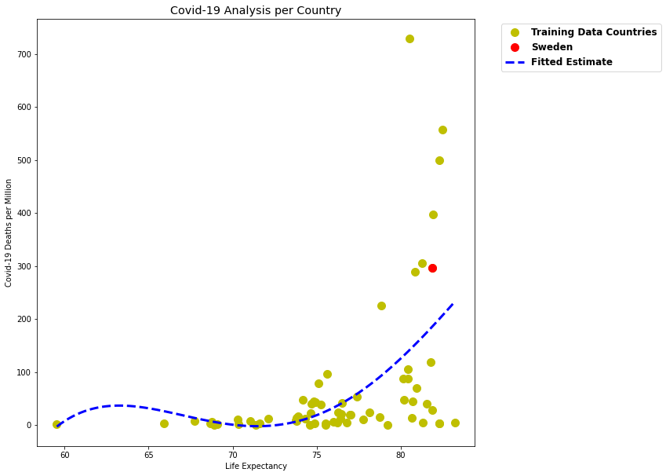

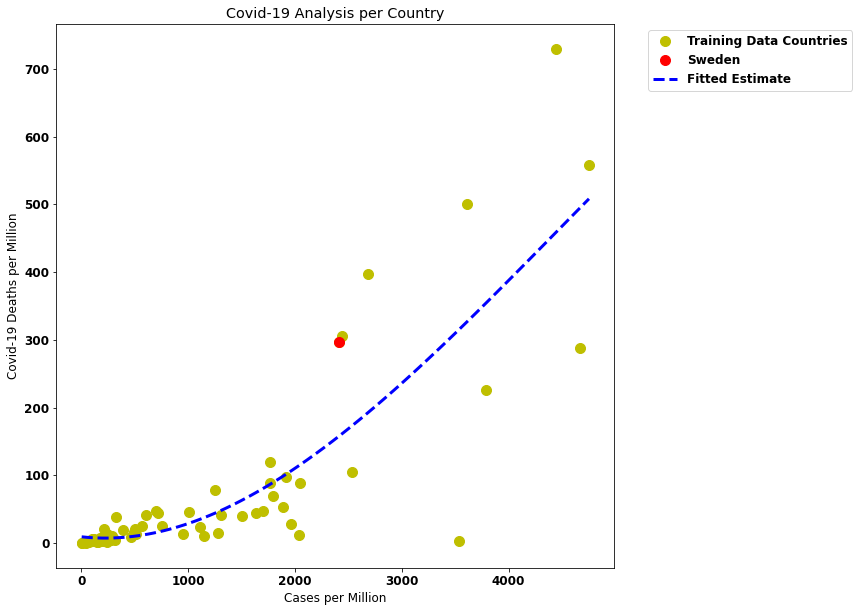

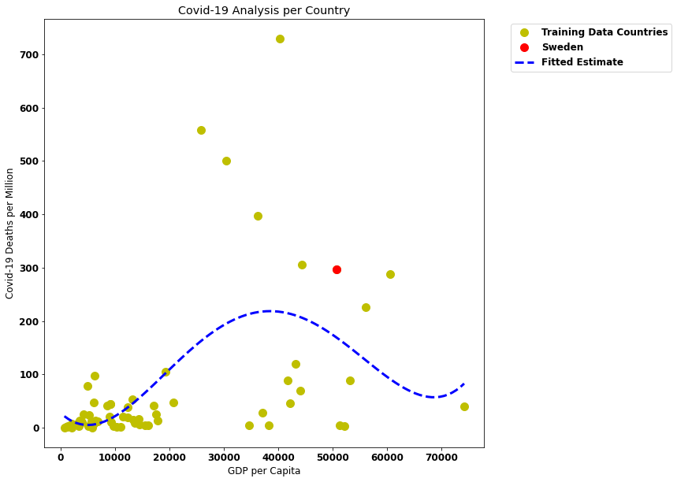

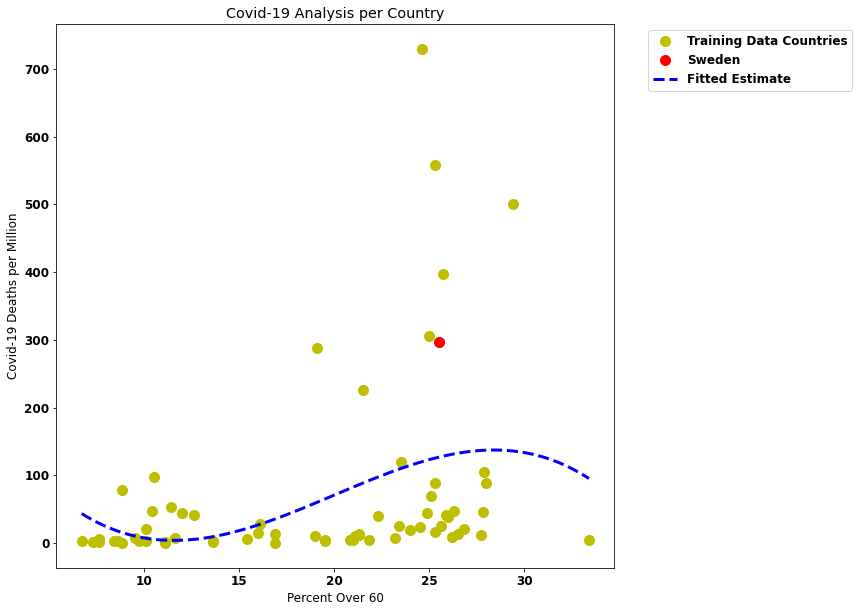

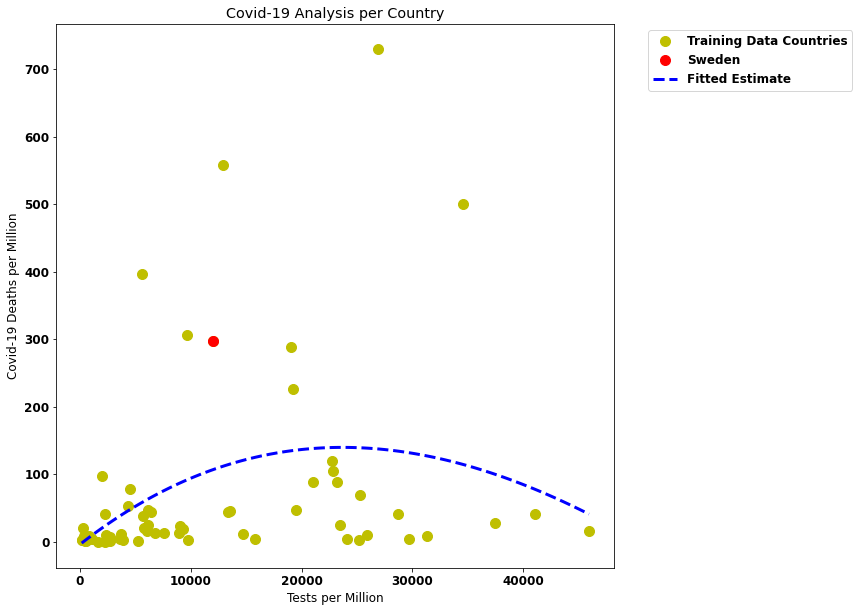

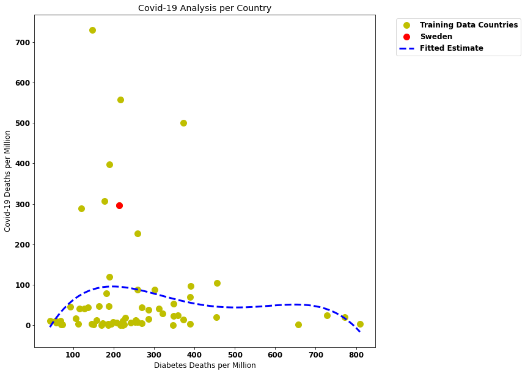

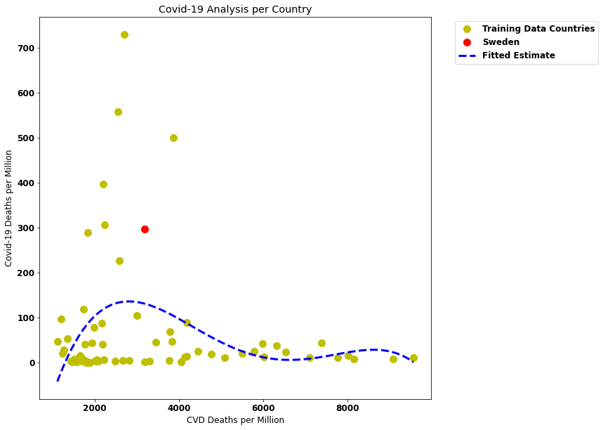

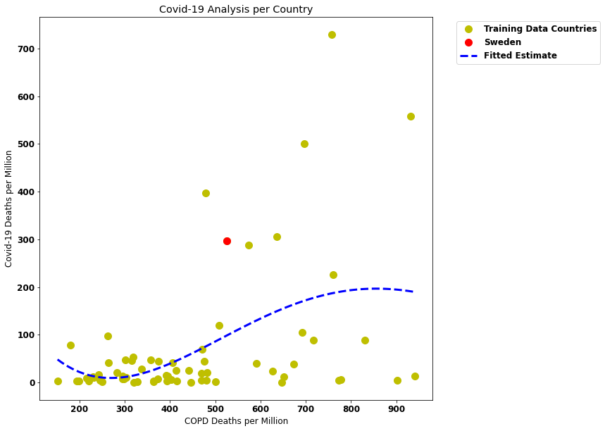

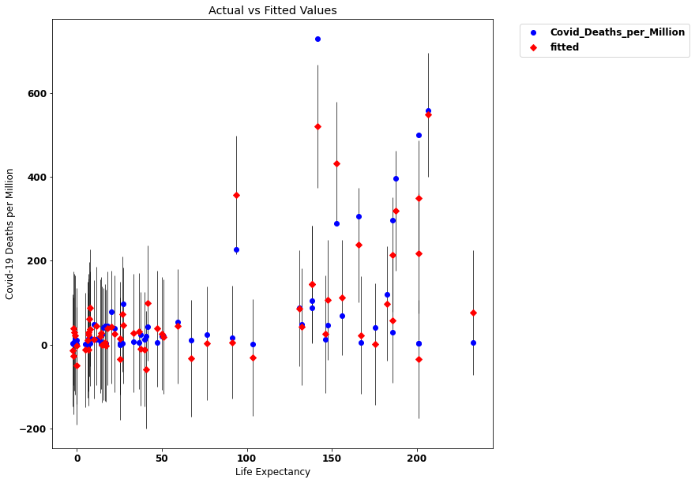

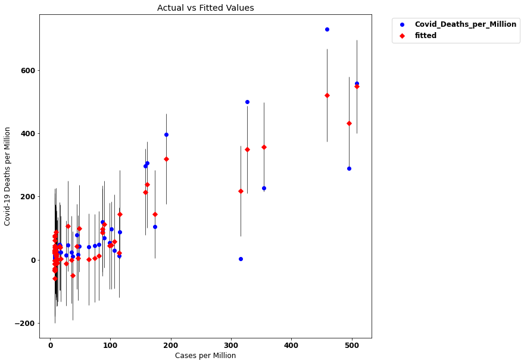

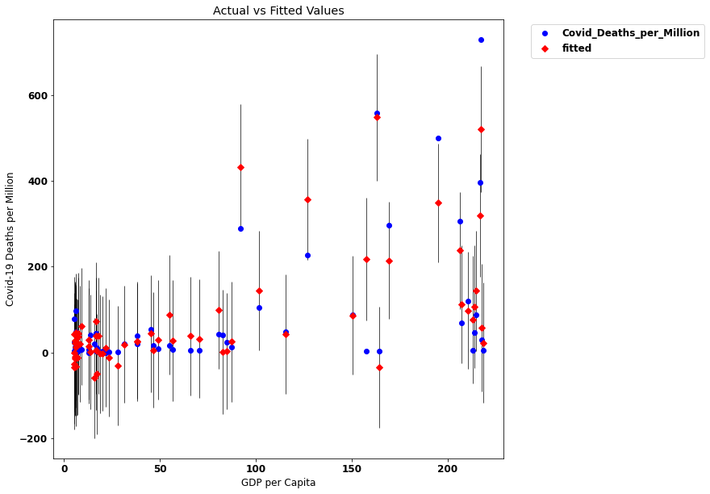

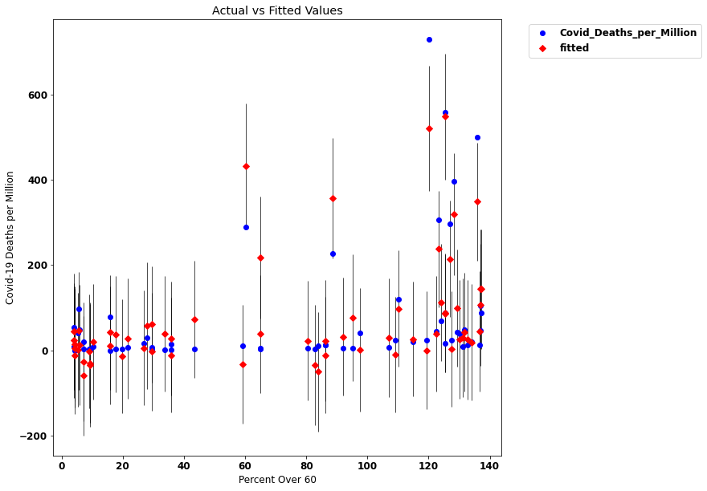

[4 more figures not shown]

```python
import statsmodels.formula.api as smf

# assign degrees for the formulas to approximate each column
colToDeg = {'Life_Expectancy' : 4,
            'Cases_per_Million' : 3,
            'GDP_per_Capita' : 4,
            'Percent_Over_60' : 3,
            'Tests_per_Million' : 3,
            'Diabetes_Deaths_per_Million' : 4,
            'CVD_Deaths_per_Million' : 4,
            'COPD_Deaths_per_Million' : 4,
           }
formulas = []

# remove outlier countries where their factors lie 3+ standard deviations away from the mean
testInfo=countryInfo
for col in colToDeg:
    testInfo = testInfo[testInfo[col].between(testInfo[col].mean()-testInfo[col].std()*3,
                                              testInfo[col].mean()+testInfo[col].std()*3)]

yArray = np.array(testInfo['Covid_Deaths_per_Million'])

for x in colToDeg:
    xArray = np.array(testInfo[x])

    # fit a polynomial for each factor in colToDeg of the relevant degree
    weight = np.polyfit(xArray, yArray, colToDeg[x])

    # add evaluated values to array to be added to ols model later
    formulas.append(np.poly1d(weight)(xArray))

    fig, ax = plt.subplots(figsize=(10,10))
    # plot each country point
    plot(xArray, yArray,'yo', label="Training Data Countries", markersize=10)
    # identify Sweden on graphs
    plot(countryInfo[x].loc['Sweden'],countryInfo['Covid_Deaths_per_Million'].loc['Sweden'],'ro',label="Sweden", markersize=10)

    # plot fitted line
    # create 100 values from the minimum to maximum of the factor
    xVals = np.linspace(xArray.min(), xArray.max(), 100)

    # evalute each "xVal" according to the fit
    font = {'weight' : 'bold', 'size' : 12}
    matplotlib.rc('font', **font)
    plot(xVals,polyval(weight,xVals),'b--', label="Fitted Estimate", linewidth=3)

    # label graphs
    plt.title("Covid-19 Analysis per Country")
    plt.xlabel(x.replace("_"," "))
    plt.ylabel("Covid-19 Deaths per Million")
    plt.legend(bbox_to_anchor=(1.05, 1), loc='upper left', borderaxespad=.5)

# create custom formula for patsy
stringFormula =  ["formulas[" + str(i) + "]"  for i in range(len(formulas))  ]
stringFormula = "+".join(stringFormula)
stringFormula = 'Covid_Deaths_per_Million ~ ' + stringFormula

model = smf.ols(formula = stringFormula, data=testInfo)

results = model.fit()

i=1
xnames = ["Intercept"]
# plot estimated vs fitted values for each predictor
for x in colToDeg:
    fig, ax = plt.subplots(figsize=(10,10))
    fig = sm.graphics.plot_fit(results, i, ax=ax)
    plt.legend(bbox_to_anchor=(1.05, 1), loc='upper left', borderaxespad=.5)
    plt.ylabel('Covid-19 Deaths per Million')
    plt.xlabel(x.replace("_"," "))
    plt.title("Actual vs Fitted Values")
    i=i+1
    xnames.append([x.replace("_"," ")])
```

The above graphs depict the predicted values for each of our predictors. We can see in the table below the overall reliability of the model with an adjusted R-squared value of .790. We can also see how significant each predictor is. Unsurprisingly, the best predictors for the covid death rate are the testing and case rates with p-values very close to 0.

```python
# display a chart summarizing our findings
results.summary(xname=xnames)
```

OLS Regression Results

| Dep. Variable: | Covid_Deaths_per_Million | R-squared: | 0.816 |
| --- | --- | --- | --- |
| Model: | OLS | Adj. R-squared: | 0.790 |
| Method: | Least Squares | F-statistic: | 31.56 |
| Date: | Thu, 07 May 2020 | Prob (F-statistic): | 3.02e-18 |
| Time: | 15:43:03 | Log-Likelihood: | -364.40 |
| No. Observations: | 66 | AIC: | 746.8 |
| Df Residuals: | 57 | BIC: | 766.5 |
| Df Model: | 8 |  |  |
| Covariance Type: | nonrobust |  |  |

|  | coef | std err | t | P>\|t\| | [0.025 | 0.975] |
| --- | --- | --- | --- | --- | --- | --- |
| Intercept | -69.6869 | 28.180 | -2.473 | 0.016 | -126.117 | -13.257 |
| ['Life Expectancy'] | -0.4146 | 0.260 | -1.595 | 0.116 | -0.935 | 0.106 |
| ['Cases per Million'] | 1.0685 | 0.090 | 11.871 | 0.000 | 0.888 | 1.249 |
| ['GDP per Capita'] | 0.5082 | 0.259 | 1.958 | 0.055 | -0.011 | 1.028 |
| ['Percent Over 60'] | 0.8385 | 0.240 | 3.487 | 0.001 | 0.357 | 1.320 |
| ['Tests per Million'] | -0.8786 | 0.241 | -3.640 | 0.001 | -1.362 | -0.395 |
| ['Diabetes Deaths per Million'] | 0.7017 | 0.327 | 2.144 | 0.036 | 0.046 | 1.357 |
| ['CVD Deaths per Million'] | 0.3904 | 0.199 | 1.961 | 0.055 | -0.008 | 0.789 |
| ['COPD Deaths per Million'] | -0.2496 | 0.177 | -1.409 | 0.164 | -0.604 | 0.105 |

| Omnibus: | 10.958 | Durbin-Watson: | 2.162 |
| --- | --- | --- | --- |
| Prob(Omnibus): | 0.004 | Jarque-Bera (JB): | 31.232 |
| Skew: | -0.122 | Prob(JB): | 1.65e-07 |
| Kurtosis: | 6.361 | Cond. No. | 859. |

Warnings:  
[1] Standard Errors assume that the covariance matrix of the errors is correctly specified.

```python
# predict Sweden results
predicts = results.predict(testInfo)
prediction = predicts['Sweden']
actual = countryInfo['Covid_Deaths_per_Million'].loc['Sweden']
percentage = (actual-prediction)/prediction*100
md('Our ols model predicts {:.2f} deaths per million people in Sweden; however, the current death rate is {:.2f} per million - a value {:.2f}% higher than expected.'.format(prediction,actual,percentage))
```

Our ols model predicts 213.98 deaths per million people in Sweden; however, the current death rate is 296.74 per million - a value 38.68% higher than expected.

The above finding would suggest that Sweden is faring worse than would be expected. However, our model is clearly far from perfect. We see in our normal probability plot for our residuals below and see that there is still room for improvement:

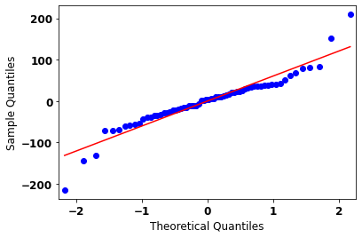

```python
#display normal probability plot
probplot = sm.ProbPlot(results.resid)
fig = probplot.qqplot(line='s')
```

Much of the error for our model comes from the extreme unpredictability of the virus itself. We therefore choose to create a quantile regression model to capture the median values and decrease our error margins.

# Quantile Analysis

```python
import warnings
warnings.filterwarnings('ignore')

# quantile regression with q=.5 for least absolute deviations
modelQ = smf.quantreg(formula = stringFormula, data=testInfo)
resultsQ = modelQ.fit(q=.5)

resultsQ.summary(xname=xnames)
```

QuantReg Regression Results

| Dep. Variable: | Covid_Deaths_per_Million | Pseudo R-squared: | 0.4806 |
| --- | --- | --- | --- |
| Model: | QuantReg | Bandwidth: | 22.81 |
| Method: | Least Squares | Sparsity: | 55.55 |
| Date: | Thu, 07 May 2020 | No. Observations: | 66 |
| Time: | 15:43:04 | Df Residuals: | 57 |
|  |  | Df Model: | 8 |

|  | coef | std err | t | P>\|t\| | [0.025 | 0.975] |
| --- | --- | --- | --- | --- | --- | --- |
| Intercept | -31.4863 | 12.027 | -2.618 | 0.011 | -55.571 | -7.402 |
| ['Life Expectancy'] | 0.0987 | 0.111 | 0.890 | 0.377 | -0.123 | 0.321 |
| ['Cases per Million'] | 1.0490 | 0.038 | 27.307 | 0.000 | 0.972 | 1.126 |
| ['GDP per Capita'] | -0.0524 | 0.111 | -0.473 | 0.638 | -0.274 | 0.169 |
| ['Percent Over 60'] | 0.3711 | 0.103 | 3.616 | 0.001 | 0.166 | 0.577 |
| ['Tests per Million'] | -0.3097 | 0.103 | -3.006 | 0.004 | -0.516 | -0.103 |
| ['Diabetes Deaths per Million'] | 0.2208 | 0.140 | 1.580 | 0.120 | -0.059 | 0.501 |
| ['CVD Deaths per Million'] | 0.1994 | 0.085 | 2.347 | 0.022 | 0.029 | 0.369 |
| ['COPD Deaths per Million'] | -0.1151 | 0.076 | -1.522 | 0.134 | -0.266 | 0.036 |

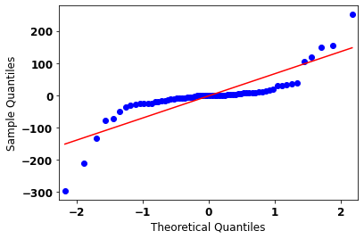

```python
#display normal probability plot
probplot = sm.ProbPlot(resultsQ.resid)
fig = probplot.qqplot(line='s')
```

This model has a pseudo R-squared of .4806, and indeed we actually find a bit more variation in some of our residuals as seen in the normal plot above. Nevertheless, this model is still useful to glean some more insight into the effectiveness of Sweden's policy.

```python
# make quantile predicitons
predictsQ = resultsQ.predict(testInfo)
predictionQ = predictsQ['Sweden']
actual = countryInfo['Covid_Deaths_per_Million'].loc['Sweden']
percentageQ = (actual-predictionQ)/predictionQ*100
md('Our quantile regression model predicts {:.2f} deaths per million people in Sweden; however, the current death rate is {:.2f} per million - a value {:.2f}% higher than expected.'.format(predictionQ,actual,percentageQ))
```

Our quantile regression model predicts 193.40 deaths per million people in Sweden; however, the current death rate is 296.74 per million - a value 53.43% higher than expected.

Under this model, we see an even higher percentage increase in Sweden's actual death toll relative to their predicted, which should serve inform us that social distancing measures are effective and should be not be loosened without caution. However, there indeed are many limitations to this model given lack of information available. In addition, Sweden's policymakers could very well have braced for a higher initial death toll in hopes of dropping their death rate sooner while keeping people's lives and the economy afloat. We cannot truly know what effect Sweden's approach will have had until this coronavirus is no longer a pandemic, but the models created here suggest that Sweden's death toll from Covid-19 is significantly higher than would be expected.